# Supervised Learning - Foundations Project: ReCell

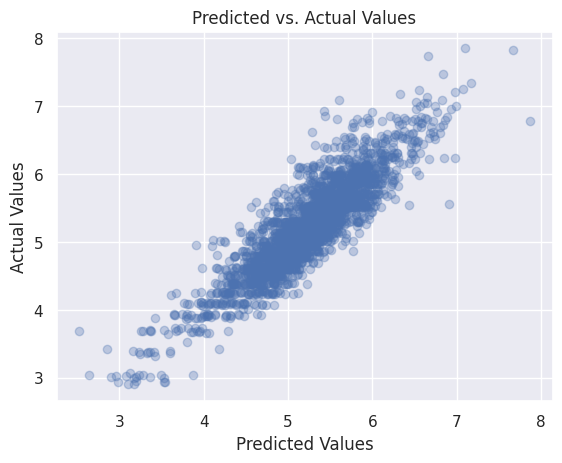

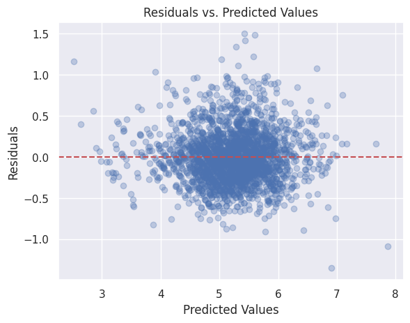

```python
#No.2 Linearity of variables
# Plotting predicted values vs actual values
plt.scatter(y_train_pred, y_train, alpha=0.3)
plt.xlabel('Predicted Values')
plt.ylabel('Actual Values')
plt.title('Predicted vs. Actual Values')
plt.show()

# Plotting residuals vs predicted values
plt.scatter(y_train_pred, y_train - y_train_pred, alpha=0.3)
plt.xlabel('Predicted Values')
plt.ylabel('Residuals')
plt.title('Residuals vs. Predicted Values')
plt.axhline(y=0, color='r', linestyle='--')
plt.show()
```

```python
#No.3 independence of error terms
from statsmodels.stats.stattools import durbin_watson

# Calculate and print Durbin-Watson statistic
dw_stat = durbin_watson(y_train - y_train_pred)
print(f"Durbin-Watson statistic: {dw_stat}")
```

```
Durbin-Watson statistic: 1.9787892703677654
```

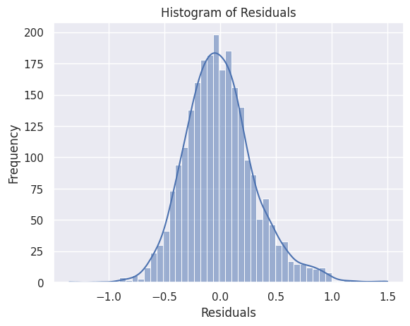

```python
# Calculate residuals
residuals = y_train - y_train_pred

# Plotting the histogram of residuals
sns.histplot(residuals, kde=True)
plt.xlabel('Residuals')
plt.ylabel('Frequency')
plt.title('Histogram of Residuals')
plt.show()
```

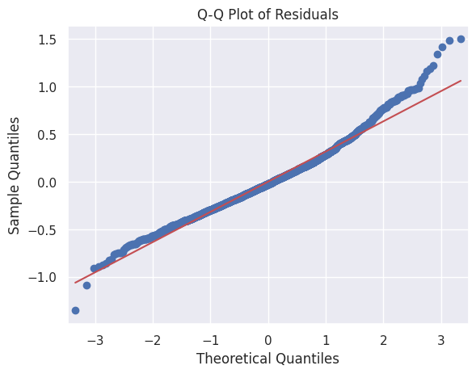

```python
#QQ Plot
import statsmodels.api as sm

# Q-Q plot for residuals
sm.qqplot(residuals, line='s')
plt.title('Q-Q Plot of Residuals')
plt.show()
```

```python
from scipy.stats import shapiro

# Shapiro-Wilk Test
stat, p_value = shapiro(residuals)
print('Shapiro-Wilk Test statistics=%.3f, p=%.3f' % (stat, p_value))

# Interpretation
if p_value > 0.05:
    print("The residuals seem to follow a normal distribution.")
else:
    print("The residuals do not seem to follow a normal distribution.")
```

```
Shapiro-Wilk Test statistics=0.980, p=0.000
The residuals do not seem to follow a normal distribution.
```

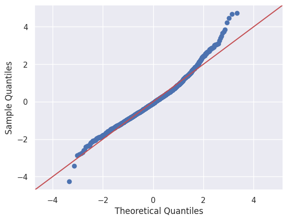

```
Shapiro-Wilk test p-value: 7.211277034995427e-18
```

```python
#No. 4 Normality of error terms
from scipy.stats import shapiro

# Q-Q plot
sm.qqplot(y_train - y_train_pred, line='45', fit=True)
plt.show()

# Shapiro-Wilk test
stat, p_value = shapiro(y_train - y_train_pred)
print(f"Shapiro-Wilk test p-value: {p_value}")
```

```
{'Lagrange multiplier statistic': 170.2838414632162, 'p-value': 1.3753828218791662e-15, 'f-value': 3.739088037563423, 'f p-value': 2.7328251586838224e-16}
```

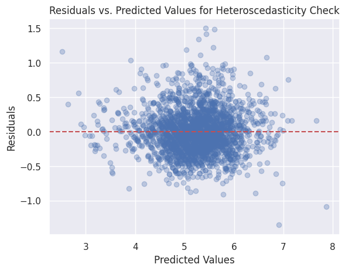

```python
#No. 5 No Heteroscedasticity using the breusch pagan test
from statsmodels.stats.diagnostic import het_breuschpagan

# Test for heteroscedasticity
bp_test = het_breuschpagan(y_train - y_train_pred, X_with_const)
labels = ['Lagrange multiplier statistic', 'p-value', 'f-value', 'f p-value']
print(dict(zip(labels, bp_test)))

# Plotting residuals vs predicted values for visual check
plt.scatter(y_train_pred, y_train - y_train_pred, alpha=0.3)
plt.xlabel('Predicted Values')
plt.ylabel('Residuals')
plt.title('Residuals vs. Predicted Values for Heteroscedasticity Check')
plt.axhline(y=0, color='r', linestyle='--')
plt.show()
```

```python
#N0.5 (ii). No heteroscedasity using the Goldfeld-Quandt test
import statsmodels.api as sm
from statsmodels.stats.diagnostic import het_goldfeldquandt

# Perform the Goldfeld-Quandt test
gq_test = het_goldfeldquandt(y_train - y_train_pred, X_with_const)

print("Goldfeld-Quandt test statistic:", gq_test[0])
print("P-value:", gq_test[1])

# Interpretation
if gq_test[1] < 0.05:
    print("Evidence of heteroscedasticity (reject H0 of homoscedasticity)")
else:
    print("No evidence of heteroscedasticity (fail to reject H0 of homoscedasticity)")
```

```
Goldfeld-Quandt test statistic: 1.0694761787787048
P-value: 0.1264653718035092
No evidence of heteroscedasticity (fail to reject H0 of homoscedasticity)
```

## Final Model

```python
# Fit the final OLS model
olsmodel_final = sm.OLS(y_train, X_with_const).fit()

# Print the summary of the final model
print(olsmodel_final.summary())
```

```
                             OLS Regression Results
================================================================================
Dep. Variable:     normalized_new_price   R-squared:                       0.789
Model:                              OLS   Adj. R-squared:                  0.785
Method:                   Least Squares   F-statistic:                     184.7
Date:                  Fri, 02 Feb 2024   Prob (F-statistic):               0.00
Time:                          23:43:29   Log-Likelihood:                -655.82
No. Observations:                  2417   AIC:                             1410.
Df Residuals:                      2368   BIC:                             1693.
Df Model:                            48
Covariance Type:              nonrobust
=========================================================================================
                            coef    std err          t      P>|t|      [0.025      0.975]
-----------------------------------------------------------------------------------------
const                     0.8921      0.106      8.436      0.000       0.685       1.099
brand_name_Alcatel       -0.0474      0.069     -0.690      0.490      -0.182       0.087
brand_name_Apple          0.6169      0.204      3.031      0.002       0.218       1.016
brand_name_Asus           0.0044      0.068      0.065      0.948      -0.129       0.138
brand_name_BlackBerry     0.1305      0.099      1.313      0.189      -0.064       0.325
brand_name_Celkon        -0.2541      0.094     -2.700      0.007      -0.439      -0.070
brand_name_Coolpad       -0.1064      0.098     -1.086      0.277      -0.298       0.086
brand_name_Gionee         0.1014      0.081      1.253      0.210      -0.057       0.260
brand_name_Google         0.5306      0.114      4.667      0.000       0.308       0.754
brand_name_HTC            0.1260      0.069      1.825      0.068      -0.009       0.261
brand_name_Honor         -0.1212      0.070     -1.731      0.084      -0.259       0.016
brand_name_Huawei         0.0233      0.064      0.365      0.715      -0.102       0.148
brand_name_Infinix       -0.3842      0.157     -2.454      0.014      -0.691      -0.077
brand_name_Karbonn       -0.1826      0.094     -1.939      0.053      -0.367       0.002
brand_name_LG             0.1190      0.065      1.842      0.066      -0.008       0.246
brand_name_Lava          -0.2024      0.087     -2.326      0.020      -0.373      -0.032
brand_name_Lenovo        -0.0951      0.065     -1.460      0.144      -0.223       0.033
brand_name_Meizu         -0.0575      0.078     -0.741      0.459      -0.210       0.095
brand_name_Micromax      -0.2004      0.068     -2.964      0.003      -0.333      -0.068
brand_name_Microsoft     -0.1574      0.113     -1.395      0.163      -0.379       0.064
brand_name_Motorola      -0.1106      0.070     -1.574      0.116      -0.248       0.027
brand_name_Nokia          0.0849      0.072      1.172      0.241      -0.057       0.227
brand_name_OnePlus        0.1895      0.101      1.872      0.061      -0.009       0.388
brand_name_Oppo           0.0561      0.068      0.827      0.408      -0.077       0.189
brand_name_Others         0.0198      0.060      0.329      0.742      -0.098       0.138
brand_name_Panasonic     -0.1603      0.085     -1.880      0.060      -0.328       0.007
```

[output cut: 19 more lines]

```
weight                   -0.0005      0.000     -2.526      0.012      -0.001      -0.000
days_used              -6.55e-05   4.24e-05     -1.546      0.122      -0.000    1.76e-05
normalized_used_price     0.7832      0.023     33.494      0.000       0.737       0.829
years_since_release       0.0873      0.006     14.337      0.000       0.075       0.099
==============================================================================
Omnibus:                      176.147   Durbin-Watson:                   1.979
Prob(Omnibus):                  0.000   Jarque-Bera (JB):              275.869
Skew:                           0.568   Prob(JB):                     1.25e-60
Kurtosis:                       4.203   Cond. No.                     1.85e+05
==============================================================================

Notes:
[1] Standard Errors assume that the covariance matrix of the errors is correctly specified.
[2] The condition number is large, 1.85e+05. This might indicate that there are
strong multicollinearity or other numerical problems.
```

```python
y_train_pred = olsmodel_final.predict(X_with_const)
```

```python
from sklearn.metrics import mean_absolute_error, mean_squared_error, r2_score
import numpy as np

def model_performance_regression(actual, predicted):
    mae = mean_absolute_error(actual, predicted)
    mse = mean_squared_error(actual, predicted)
    rmse = np.sqrt(mse)
    r2 = r2_score(actual, predicted)
    return {'MAE': mae, 'MSE': mse, 'RMSE': rmse, 'R²': r2}
```

```python
# Assuming the function model_performance_regression requires actual values and predicted values as inputs
olsmodel_final_train_perf = model_performance_regression(y_train, y_train_pred)
print("Training Performance\n")
print(olsmodel_final_train_perf)
```

```
Training Performance

{'MAE': 0.24357175229181233, 'MSE': 0.10074115429769565, 'RMSE': 0.3173974705281938, 'R²': 0.789190528545263}
```

## Actionable Insights and Recommendations

The model's performance metrics, such as MAE, MSE, and RMSE, indicate a reliable prediction capability with relatively low error rates, suggesting that our model can be a valuable tool for developing dynamic pricing strategies for used and refurbished devices.

# Recommendations

Based on our findings, several actionable recommendations can be made to ReCell to capitalize on the growing market for used and refurbished devices:

## Dynamic Pricing Strategy:

Implement a machine learning-based dynamic pricing model that adjusts the prices of used devices in real time, considering their specifications and market demand. This strategy can enhance competitiveness and profitability.

## Focus on Quality Attributes:

Highlight devices with higher RAM, better cameras, and larger screen sizes in marketing efforts. These attributes significantly influence pricing and consumer decision-making.

## Warranty and Insurance Offers:

Given the importance of device condition in determining used device prices, offering warranties and insurance on refurbished devices can increase their value and appeal to customers.

## Sustainability Marketing:

Emphasize the environmental benefits of purchasing used and refurbished devices, such as reducing e-waste and promoting recycling. This appeals to environmentally conscious consumers and aligns with global sustainability trends.

## Targeted Inventory Acquisition:

Prioritize acquiring devices that retain value longer, such as those with 5G capability, higher internal memory, and brands known for durability. This approach can improve inventory value over time.

## Expand Consumer Base:

Leverage the model's insights to target demographics more likely to purchase refurbished devices, such as cost-conscious consumers and businesses looking for cost-effective solutions.

## Adapt to COVID-19 Impact:

Capitalize on the increased demand for affordable devices due to the COVID-19 pandemic by offering deals and promotions on essential devices for remote work and education.

## Market Analysis:

Use the model's insights for market analysis, identifying emerging trends and consumer preferences to stay ahead in the competitive landscape.

## Educational Campaigns:

Educate consumers on the benefits and reliability of refurbished devices to dispel any misconceptions and encourage adoption.

By adopting these recommendations, ReCell can position itself as a leader in the used and refurbished device market.

```python
!jupyter nbconvert --to html "//content/SLF_Project_LearnerNotebook_FullCode MUGOTITSA B(1).ipynb"
```

[output not shown]

[output cut: 133 more lines]

[output not shown]

```python
from google.colab import drive
drive.mount('/content/drive')
```